# DSCC462_FinalProject

Q6.(e)

```r
#part - e
set.seed(23234)
model1 <- lm(advertise_df$profit ~ advertise_df$adcost)
model1
```

```
##
## Call:
## lm(formula = advertise_df$profit ~ advertise_df$adcost)
##
## Coefficients:
##         (Intercept)  advertise_df$adcost
##              264.87               -18.75
```

```r
summary(model1)
```

```
##
## Call:
## lm(formula = advertise_df$profit ~ advertise_df$adcost)
##
## Residuals:
##    Min     1Q Median     3Q    Max
## -290.0 -159.4  -60.7   69.3 3902.4
##
## Coefficients:
##                     Estimate Std. Error t value Pr(>|t|)
## (Intercept)           264.87      31.46   8.419 6.50e-16 ***
## advertise_df$adcost   -18.75       4.45  -4.214 3.09e-05 ***
## ---
## Signif. codes:  0 '***' 0.001 '**' 0.01 '*' 0.05 '.' 0.1 ' ' 1
##
## Residual standard error: 317.2 on 408 degrees of freedom
## Multiple R-squared:  0.04171,    Adjusted R-squared:  0.03936
## F-statistic: 17.76 on 1 and 408 DF,  p-value: 3.089e-05
```

```r
beta0 <- 264.87
beta1 <- -18.75
yhat <- paste( beta0 ," + ", beta1 ,"*X...where X is adcost")

paste("The prediction equation is - ", yhat)
```

```
## [1] "The prediction equation is -  264.87  +  -18.75 *X...where X is adcost"
```

```r
confint(model1, level = 0.90)
```

```
##                          5 %     95 %
## (Intercept)         213.0086 316.7396
## advertise_df$adcost -26.0897 -11.4170
```

```r
#Coefficient of determination

paste("Coefficient of determination: ",summary(model)$r.squared)
```

[output not shown]

Q6.(f)

```r
set.seed(23234)
model2 <- lm(advertise_df$profit ~ advertise_df$adcost+ advertise_df$age)
model2
```

```
##
## Call:
## lm(formula = advertise_df$profit ~ advertise_df$adcost + advertise_df$age)
##
## Coefficients:
##         (Intercept)  advertise_df$adcost     advertise_df$age
##             230.807              -20.116                1.591
```

```r
summary(model2)
```

```
##
## Call:
## lm(formula = advertise_df$profit ~ advertise_df$adcost + advertise_df$age)
##
## Residuals:
##    Min     1Q Median     3Q    Max
## -328.2 -157.6  -64.1   76.4 3911.0
##
## Coefficients:
##                     Estimate Std. Error t value Pr(>|t|)
## (Intercept)          230.807     50.210   4.597 5.73e-06 ***
## advertise_df$adcost  -20.116      4.719  -4.263 2.51e-05 ***
## advertise_df$age       1.591      1.827   0.871    0.384
## ---
## Signif. codes:  0 '***' 0.001 '**' 0.01 '*' 0.05 '.' 0.1 ' ' 1
##
## Residual standard error: 317.3 on 407 degrees of freedom
## Multiple R-squared:  0.04349,    Adjusted R-squared:  0.03879
## F-statistic: 9.254 on 2 and 407 DF,  p-value: 0.0001175
```

Q6.(g)

```r
anova(model1, model2)
```

```
## Analysis of Variance Table
##
## Model 1: advertise_df$profit ~ advertise_df$adcost
## Model 2: advertise_df$profit ~ advertise_df$adcost + advertise_df$age
##   Res.Df      RSS Df Sum of Sq      F Pr(>F)
## 1    408 41063614
## 2    407 40987258  1     76356 0.7582 0.3844
```

Since the test statistic i.e. F value is not significant, thus adding age to the model didn’t perform better over the model with just adcost. In context to the problem, we can intrepret that adcost is a better indicator of profit than age.

Q.7

We are given $100 to spend on the advertisement. In general, an ad is more effective only when the user comes across it multiple times. In that way it stays in the user’s mind which gives us an edge when the user makes a purchasing decision. Additionally, $100 is not a huge amount to be distributed into multiple targeted segments. Hence, we would spend the entire amount into a single targeted group of users.

Importing the dataset

```r
ads <- read.csv("ads6.csv")
summary(ads)
```

```
##  socialmedia             age           mobile             season
##  Length:410         Min.   :10.00   Length:410         Length:410
##  Class :character   1st Qu.:19.00   Class :character   Class :character
##  Mode  :character   Median :26.00   Mode  :character   Mode  :character
##                     Mean   :26.67
##                     3rd Qu.:32.00
##                     Max.   :52.00
##  newcustomer            adcost         adrevenue
##  Length:410         Min.   : 0.030   Min.   : 0.230
##  Class :character   1st Qu.: 3.520   1st Qu.: 4.095
##  Mode  :character   Median : 5.600   Median : 8.295
##                     Mean   : 6.131   Mean   :12.996
##                     3rd Qu.: 7.880   3rd Qu.:15.935
##                     Max.   :14.930   Max.   :93.730
```

Checking amount of data for each social media platform

```r
library("dplyr")
df <- ads %>% dplyr::count(socialmedia)
df$pct_data = (df$n/sum(df$n))*100
df
```

```
##   socialmedia   n  pct_data
## 1    Facebook  57 13.902439
## 2   Instagram  85 20.731707
## 3      TikTok 131 31.951220
## 4     Twitter  18  4.390244
## 5     YouTube 119 29.024390
```

Creating a column for profit % and grouping age

```r
ads$profit <- ads$adrevenue / ads$adcost
summary(ads$profit)
```

```
##     Min.  1st Qu.   Median     Mean  3rd Qu.     Max.
##  0.02848  0.92253  1.62669  2.49905  3.10475 42.66667
```

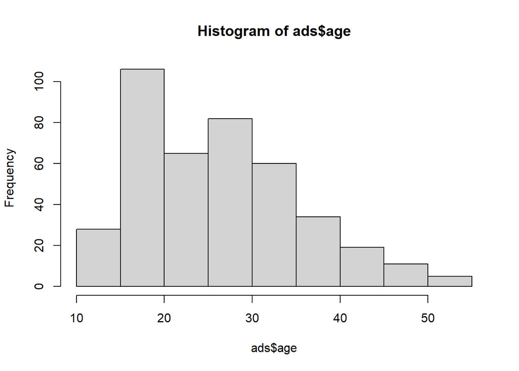

```r
hist(ads$age)
```

```r
#Using equal frequency binning to group the age

library(classInt)
x = classIntervals(ads$age, 5, style = 'quantile')
x
```

```
## style: quantile
##   one of 111,930 possible partitions of this variable into 5 classes
## [10,18) [18,23) [23,28) [28,35) [35,52]
##      63     100      74      88      85
```

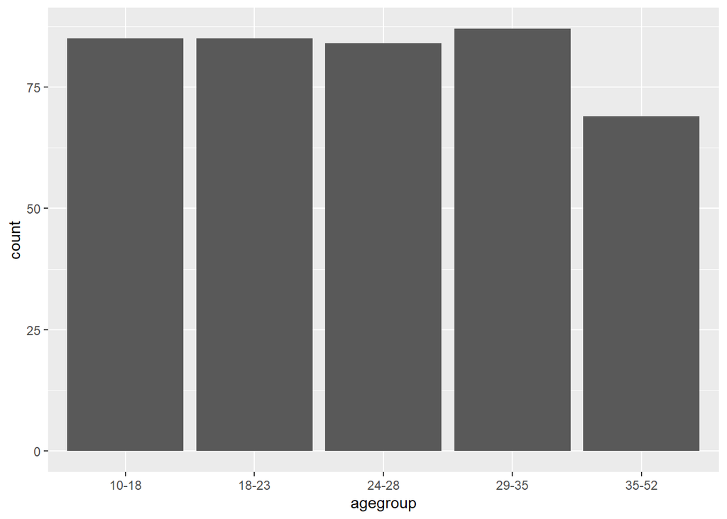

```r
ads["agegroup"] = cut(ads$age, c(0, 18, 23, 28, 35, Inf), c("10-18", "18-23", "24-28", "29-35", "35-52"), include.lowest=TRUE)
ggplot(ads, aes(x=agegroup)) + geom_bar()
```

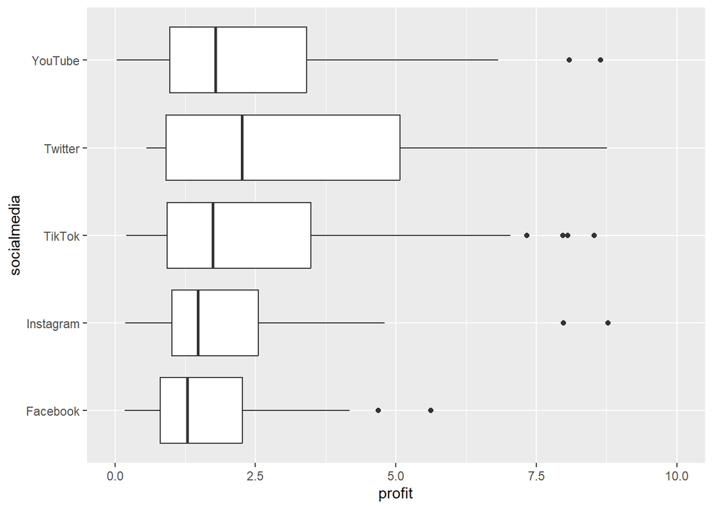

```r
library(ggplot2)
ggplot(ads, aes(x = profit, y = socialmedia)) + geom_boxplot() + xlim(0, 10)
```

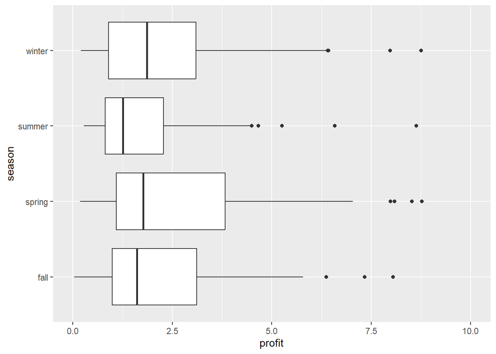

```r
ggplot(ads, aes(x = profit, y = season)) + geom_boxplot() + xlim(0, 10)
```

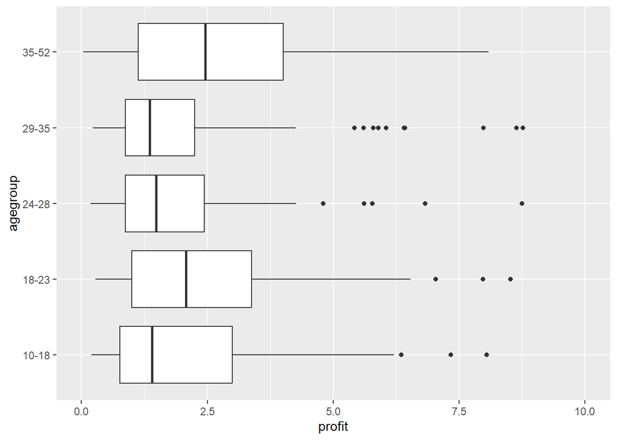

```r
ggplot(ads, aes(x = profit, y = agegroup)) + geom_boxplot() + xlim(0, 10)
```

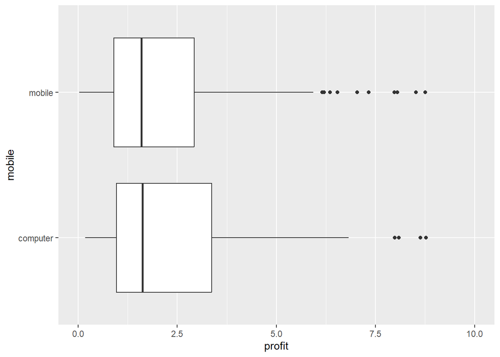

```r
ggplot(ads, aes(x = profit, y = mobile)) + geom_boxplot() + xlim(0, 10)
```

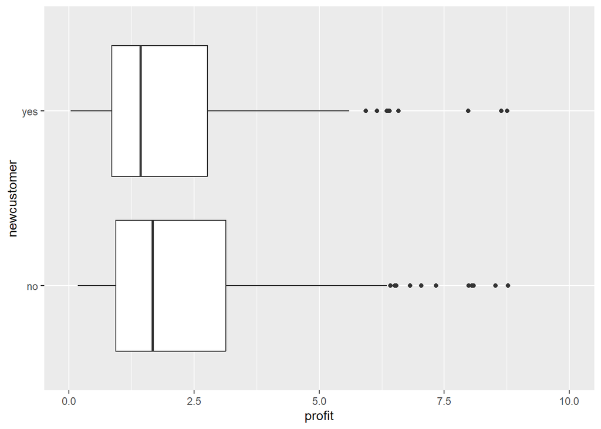

```r
ggplot(ads, aes(x = profit, y = newcustomer)) + geom_boxplot() + xlim(0, 10)
```

Looking at the distributions and medians for each attribute, ‘socialmedia’ and ‘agegroup’ show the maximum variation of median among its values. With Twitter having the maximum median in socialmedia, we cannot be sure because of the low amount of data we have for twitter. Next, the median values for TikTok and YouTube are almost in the similar range. We do not have a clear winner considering this scenario. In case of age groups, the 35-52 age bucket has the maximum median. This makes sense because that is generally an age where you are financially stable and have larger spending capacity. Hence, we will target the 35-52 age group.

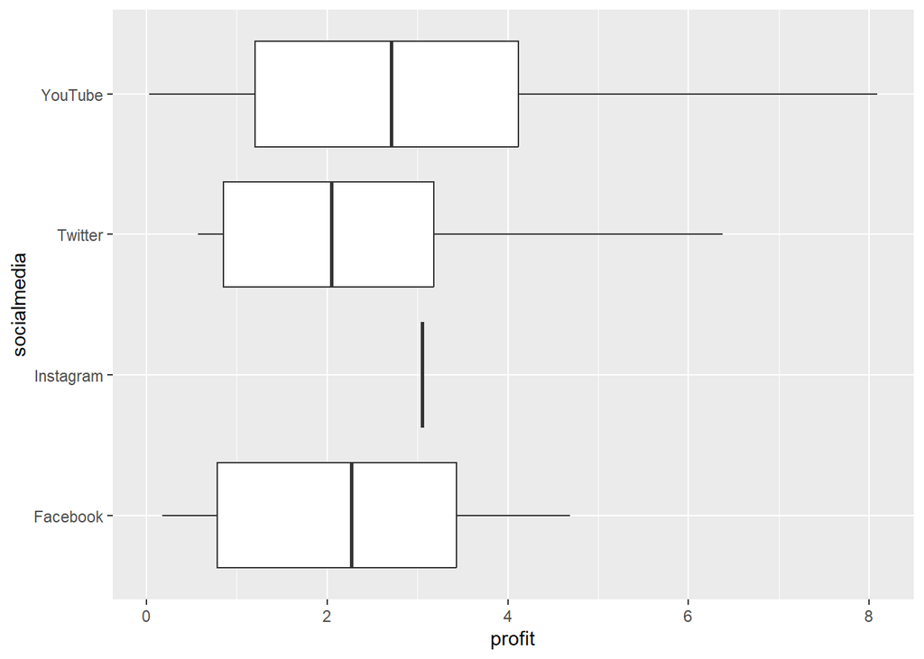

```r
ads_35plus <- ads[ads$agegroup == "35-52",]

ggplot(ads_35plus, aes(x = profit, y = socialmedia)) + geom_boxplot()
```

```r
#ggplot(ads_35plus, aes(x = profit, y = season)) + geom_boxplot()
#ggplot(ads_35plus, aes(x = profit, y = mobile)) + geom_boxplot()
#ggplot(ads_35plus, aes(x = profit, y = newcustomer)) + geom_boxplot()

df2 <- ads_35plus %>% dplyr::count(socialmedia)
df2$pct_data = (df2$n/sum(df2$n))*100
df2
```

```
##   socialmedia  n  pct_data
## 1    Facebook 15 21.739130
## 2   Instagram  1  1.449275
## 3     Twitter  9 13.043478
## 4     YouTube 44 63.768116
```

```r
ads_35plus_yt <- ads[ads$socialmedia == "YouTube",]

df3 <- ads_35plus_yt %>% dplyr::count(mobile)
df3$pct_data = (df3$n/sum(df3$n))*100
df3
```

```
##     mobile  n pct_data
## 1 computer 91 76.47059
## 2   mobile 28 23.52941
```